# R Notebook

We start by loading our results from the previous week

```r
library(DESeq2)
library(dplyr)
## Read the annotated results
results_tgf <- readRDS("Robjects/results_TGF_vs_CTR_annotated_BACKUP.rds")
## Read the counts that we produced previously
dds <- readRDS("Robjects/dds_BACKUP.rds")
```

# Exercise: Volcano plot

The standard volcano plot can be produced with the `ggplot2` package

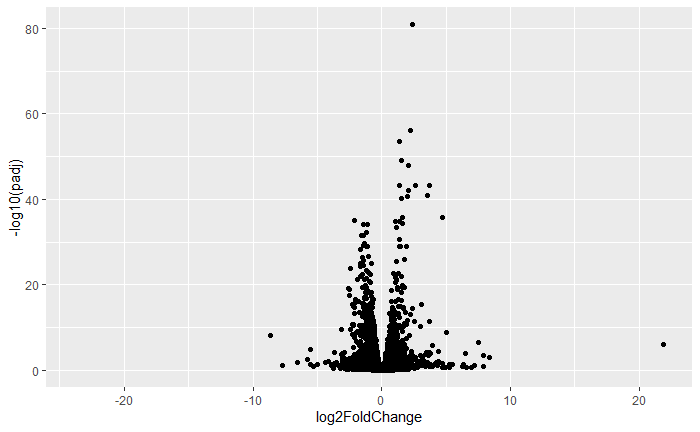

```r
library(ggplot2)
results_tgf %>%
  ggplot(aes(x = log2FoldChange, y = -log10(padj))) + geom_point()
```

```r
library(org.Hs.eg.db)
ecm_anno <- AnnotationDbi::select(org.Hs.eg.db,
                                 keys = "GO:0030198",
                                 keytype = "GO",
                                 columns=c("ENSEMBL","SYMBOL"))
ecm_anno
```

| GO | EVIDENCE | ONTOLOGY | ENSEMBL | SYMBOL |
| --- | --- | --- | --- | --- |
| GO:0030198 | ISS | BP | ENSG00000105290 | APLP1 |
| GO:0030198 | ISS | BP | ENSG00000142192 | APP |
| GO:0030198 | ISS | BP | ENSG00000165240 | ATP7A |
| GO:0030198 | IEA | BP | ENSG00000069399 | BCL3 |
| GO:0030198 | IBA | BP | ENSG00000108821 | COL1A1 |
| GO:0030198 | IBA | BP | ENSG00000164692 | COL1A2 |
| GO:0030198 | IBA | BP | ENSG00000139219 | COL2A1 |
| GO:0030198 | IBA | BP | ENSG00000168542 | COL3A1 |
| GO:0030198 | IBA | BP | ENSG00000187498 | COL4A1 |
| GO:0030198 | IBA | BP | ENSG00000134871 | COL4A2 |

[output cut: 176 more lines]

```r
ecm_ids <- pull(ecm_anno, "ENSEMBL")
```

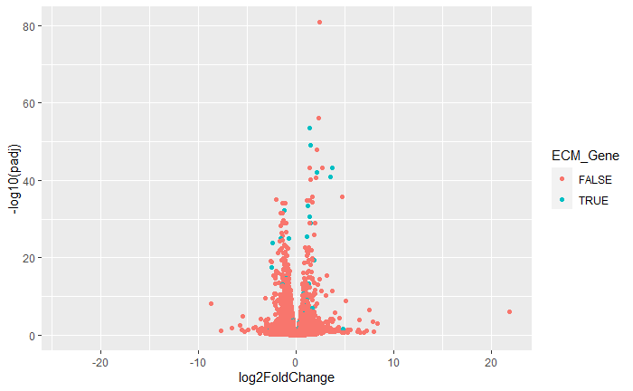

```r
results_tgf %>%
  mutate(ECM_Gene = ENSEMBL %in% ecm_ids) %>%
  ggplot(aes(x = log2FoldChange, y = -log10(padj),col=ECM_Gene)) + geom_point()
```

The default colouring does not distinguish the ECM genes as much as we might like. We could manually adjust it so that genes belonging to the pathway are coloured in red, and the rest in black. The transparency (`alpha`) can also be adjusted. Below is a suggestion.

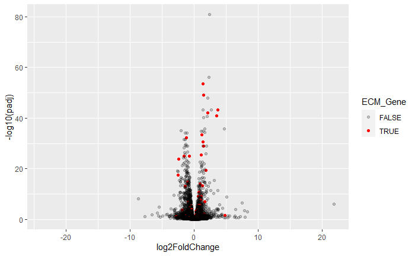

```r
results_tgf %>%
  mutate(ECM_Gene = ENSEMBL %in% ecm_ids) %>%
  ggplot(aes(x = log2FoldChange, y = -log10(padj),col=ECM_Gene,alpha=ECM_Gene)) + geom_point() + scale_color_manual(values=c("black","red")) + scale_alpha_manual(values=c(0.2,1))
```

# Exercise: Heatmap

The tricky part of making a heatmap is deciding which genes to include. The gene names have to be in ENSEMBL format, as the count matrix we will be plotting has ENSEMBL names in the rows.

```r
# The pheatmap library is needed to make the heatmap

library(pheatmap)

#first, get variance-stablised counts

vsd <- vst(dds)
```

```
using 'avgTxLength' from assays(dds), correcting for library size
```

```r
sampleInfo <- as.data.frame(colData(dds)[,c("condition","Treated")])

# create a new table that includes gene variability

res_with_var <- mutate(results_tgf, GeneVar = rowSds(assay(vsd))) %>%
  filter(!is.na(padj))

# arrange by the new column and extract ENSEMBL ID of the first 100 rows

genes_to_plot <- arrange(res_with_var, desc(GeneVar)) %>%
  dplyr::slice(1:100) %>%
  pull(ENSEMBL)
```

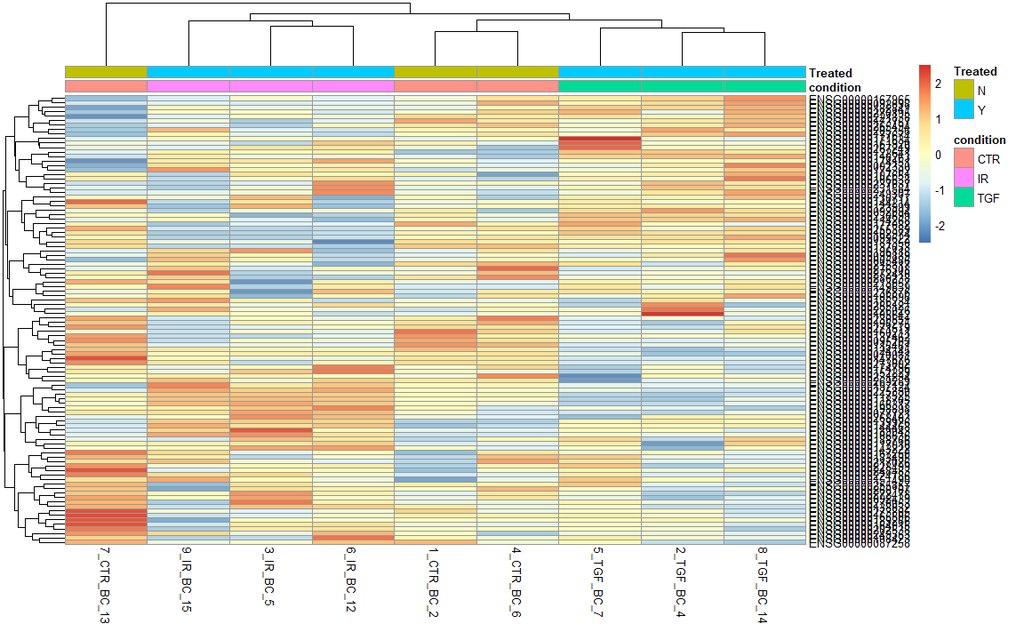

```r
pheatmap(assay(vsd)[genes_to_plot,],
         annotation_col = sampleInfo,
         scale="row")
```

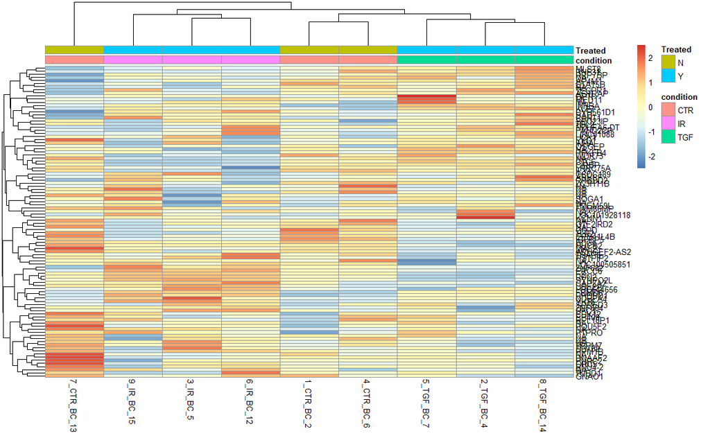

```r
gene_labels <- arrange(res_with_var, desc(GeneVar)) %>%
  dplyr::slice(1:100) %>%
  pull(SYMBOL)

pheatmap(assay(vsd)[genes_to_plot,],
         annotation_col = sampleInfo,
         labels_row = gene_labels,
         scale="row")
```

# Exercise: Pathways

**Need to fix, as currently this doesn’t return anything!**

In order to use the `enrichKEGG` function, we will have to define a set of enriched genes in terms of their `ENTREZID` (instead of `ENSEMBL`)

```r
sigGenesEntrez <- results_tgf %>%
  filter(padj < 0.05, !is.na(ENTREZID)) %>% pull(ENTREZID)
```

Make sure you check the help for `enrichKEGG`, as it uses different argument names

```r
dotplot(enrich_kegg)
```

[output not shown]

[output not shown]

Again, make sure to check the arguments for `gseKEGG`.